# tp_final_instrumentos

icalb

2022-10-28

```r
library(tidyverse)
lista_BP <- read.csv("data/2022-07-13_info_publica.csv", stringsAsFactors = TRUE)
```

¿Cómo se distribuyó espacialmente en los últimos años la inversión en proyectos o programas de integración socio urbana de barrios populares en Argentina?

La cuestión del financiamiento de integración de barrios marginados es uno de los principales temas de debate de la agenda urbana actual. Existen más de 1 billón de personas en el mundo que viven en asentamientos informales, y que no logran un satisfacer sus necesidades básicas ni acceder a los derechos más elementales que se establecen en las distintas naciones y organismos internacionales. La inversión estatal no alcanza para atender la magnitud de la problemática, y se estima que se necesitaría un presupuesto de 6 trillones de dólares a nivel mundial para formalizar e integrar a todas las personas. En África y Latinoamérica es donde este problema se revela más evidente y donde representa un desafío clave para el desarrollo de las naciones. Este escenario nos indica que es necesario, por un lado, generar fuentes de financiamiento creativas e innovadoras que sumen al capital privado en pos de la integración socio urbana y la garantía de acceso a derechos básicos, y por otro, generar el uso más eficiente posible de los recursos públicos. En este trabajo me concentraré en la segunda cuestión mencionada, preguntándome si en los últimos años en Argentina, la distribución espacial de los fondos públicos fue utilizada de manera eficiente, y a que criterios respondió esta distribución. Por último, intentaré plantear algunas iniciativas para mejorar la eficiencia en el uso de los fondos del estado para la integración de los barrios populares.

```r
library(dplyr)
```

En Argentina existen 5.687 Barrios Populares, distribuidos en todo el territorio del país. Estos barrios precarios ocupan en total 590 km2, el equivalente a casi 3 veces la superficie de la Ciudad Autónoma de Buenos Aires, y están habitadas por 1,2 millón de familias, equivalentes a 5.280.000 personas.

Es interesante ver como están distribuidos los barrios populares, y la cantidad de familias que albergan en las distintas provincias.

```r
familias_provincia_BP <- lista_BP %>%
  group_by(provincia) %>%
  summarise(total_familias = sum(cantidad_familias_aproximada))
head(familias_provincia_BP, 100)
```

```
## # A tibble: 24 × 2
##    provincia                       total_familias
##    <fct>                                    <dbl>
##  1 Buenos Aires                            573932
##  2 Catamarca                                 2871
##  3 Chaco                                    51639
##  4 Chubut                                    9524
##  5 Ciudad Autónoma de Buenos Aires          81280
##  6 Córdoba                                     NA
##  7 Corrientes                               25552
##  8 Entre Ríos                               25140
##  9 Formosa                                  24721
## 10 Jujuy                                    17160
## # … with 14 more rows
```

Observamos que la Provincia de Buenos Aires reúne casi la mitad de las familias que habitan en Barrios Populares, concentrando en poca extensión de territorio, la mayor cantidad de personas en barrios informales.

Veamos como se distribuye la extensión en m2 de los Barrios populares por provincia

```r
superficie_familias_provincia_BP <-lista_BP %>%
  group_by(provincia) %>%
  summarise(total_familias = sum(cantidad_familias_aproximada),
           total_superficie = sum(superficie_m2))
head(superficie_familias_provincia_BP,100)
```

```
## # A tibble: 24 × 3
##    provincia                       total_familias total_superficie
##    <fct>                                    <dbl>            <int>
##  1 Buenos Aires                            573932        234198930
##  2 Catamarca                                 2871          1782376
##  3 Chaco                                    51639         40028394
##  4 Chubut                                    9524          9844498
##  5 Ciudad Autónoma de Buenos Aires          81280          3195007
##  6 Córdoba                                     NA         19087155
##  7 Corrientes                               25552         16931531
##  8 Entre Ríos                               25140         11797983
##  9 Formosa                                  24721         22312718
## 10 Jujuy                                    17160          5463537
## # … with 14 more rows
```

```r
library(ggplot2)
```

```r
library(sf)
BP_geo <- st_read("data/2022-07-13_info_publica.gpkg")
```

```r
library(ggplot2)
```

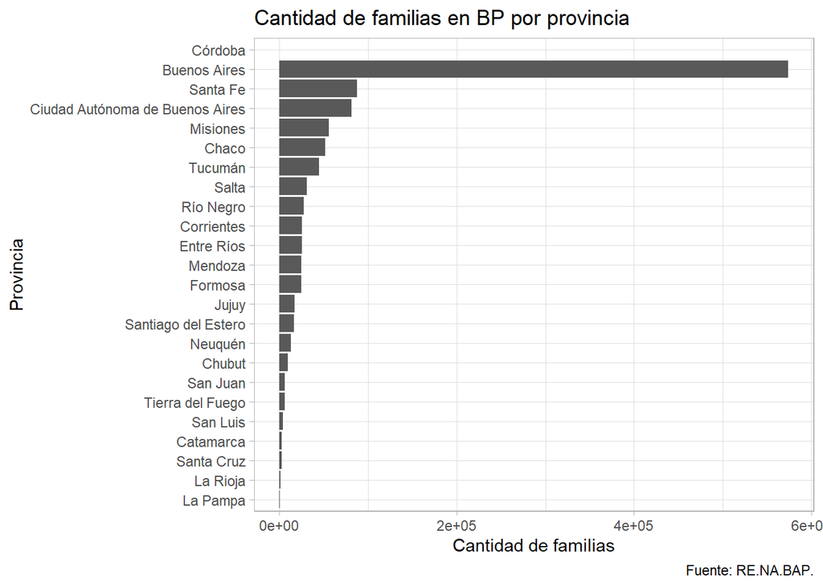

```r
ggplot(superficie_familias_provincia_BP) +
  geom_bar(aes(x=reorder(provincia, total_familias), weight=total_familias))+
  labs(title="Cantidad de familias en BP por provincia",
       fill="Zona",
       x="Provincia",
       y="Cantidad de familias",
       caption="Fuente: RE.NA.BAP.") +
  theme_light()+
  coord_flip()
```

```r
py_fisu <- read.csv("data/proyectos_fisu-2022-07-27.csv", stringsAsFactors = TRUE)
```

```r
dim(py_fisu)
```

```
## [1] 729  13
```

```r
library(tidyverse)
```

```r
fisu_agrupados <- py_fisu %>%
  group_by (provincia) %>%
  summarise (monto_total_provincia=sum(monto_total))
```

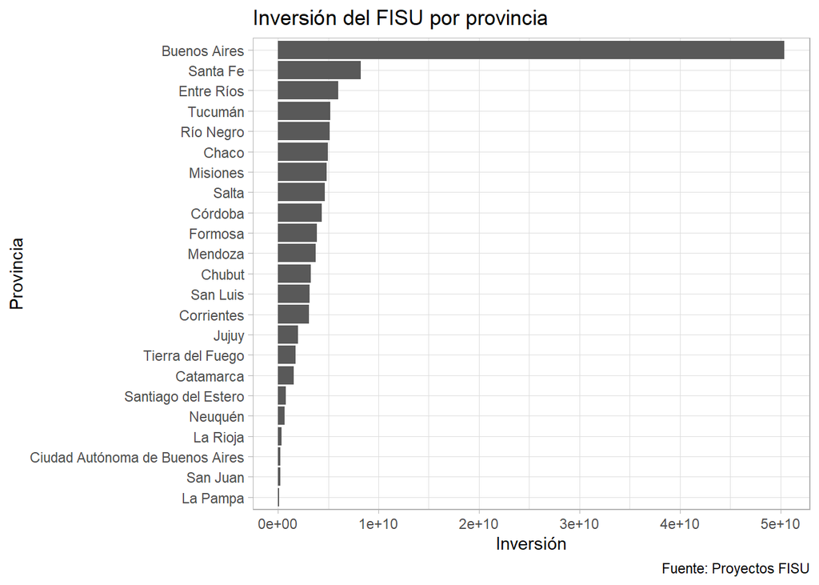

```r
ggplot(fisu_agrupados) +
  geom_bar(aes(x=reorder(provincia, monto_total_provincia), weight=monto_total_provincia))+
  labs(title="Inversión del FISU por provincia",
       fill="",
       x="Provincia",
       y="Inversión",
       caption="Fuente: Proyectos FISU") +
  theme_light()+
  coord_flip()
```

Cómo se distribuye la cantidad de familias habitantes de Barrios populares en la Provincia de Buenos Aires, por departamento

```r
BP_PBA <-
  filter (lista_BP, provincia =="Buenos Aires")
```

```r
familias_BP_PBA <- BP_PBA %>%
  group_by(departamento) %>%
  summarise(total_familias = sum(cantidad_familias_aproximada))
```

```r
head(familias_BP_PBA,135)
```

```
## # A tibble: 89 × 2
##    departamento    total_familias
##    <fct>                    <dbl>
##  1 25 de mayo                 632
##  2 9 de julio                 237
##  3 Almirante Brown          21982
##  4 Arrecifes                  353
##  5 Avellaneda               11881
##  6 Azul                       480
##  7 Bahía Blanca              6201
##  8 Balcarce                   117
##  9 Baradero                   791
## 10 Berazategui               1664
## # … with 79 more rows
```

Veamos los 20 distritos con más familias habitantes de barrios populares

```r
familias_BP_PBA <- filter(familias_BP_PBA,total_familias >= 9000 )
```

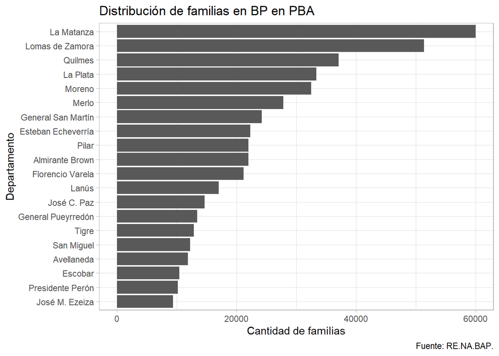

```r
ggplot(familias_BP_PBA) +
  geom_bar(aes(x=reorder(departamento, total_familias), weight=total_familias))+
  labs(title="Distribución de familias en BP en PBA",
       fill="",
       x="Departamento",
       y="Cantidad de familias",
       caption="Fuente: RE.NA.BAP.") +
  theme_light()+
  coord_flip()
```

Ahora veamos como se distribuye la inversión del FISU en la Provincia de Buenos Aires

```r
departamentos_pba <- st_read('data/Partidos.geojson')
```

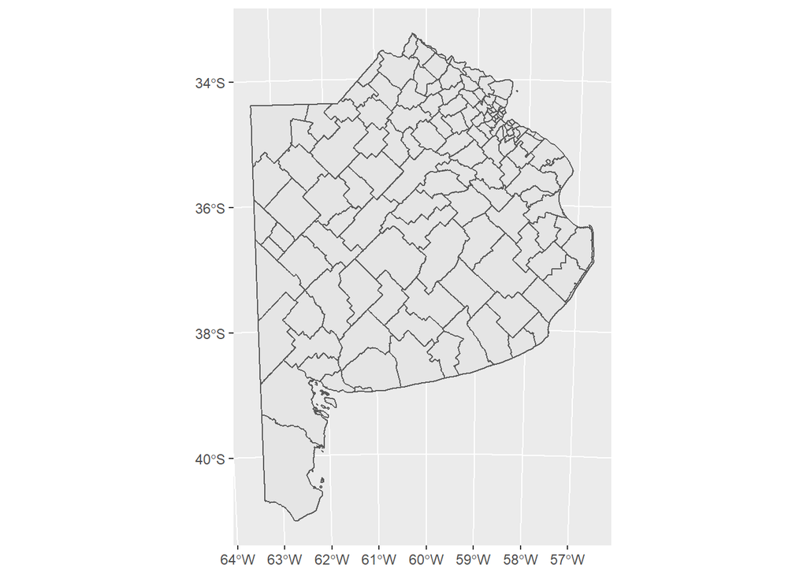

```r
ggplot(departamentos_pba)+
geom_sf()
```

```r
fisu_BP_familias_inversion <- merge(x = py_fisu, y = lista_BP, by = "renabap_id")
```

```r
fisu_BP_familias_inversion <- filter(fisu_BP_familias_inversion, provincia.x == "Buenos Aires" )
```

```r
fisu_BP_familias_inversion <- rename(fisu_BP_familias_inversion, nam=municipio)
```

```r
fisu_BP_familias_inversion <- select(fisu_BP_familias_inversion, nam, provincia.x, monto_total, cantidad_familias_aproximada)
```

```r
inversion_fisu_pba <- left_join(departamentos_pba, fisu_BP_familias_inversion, by=c("nam"="nam"))
```

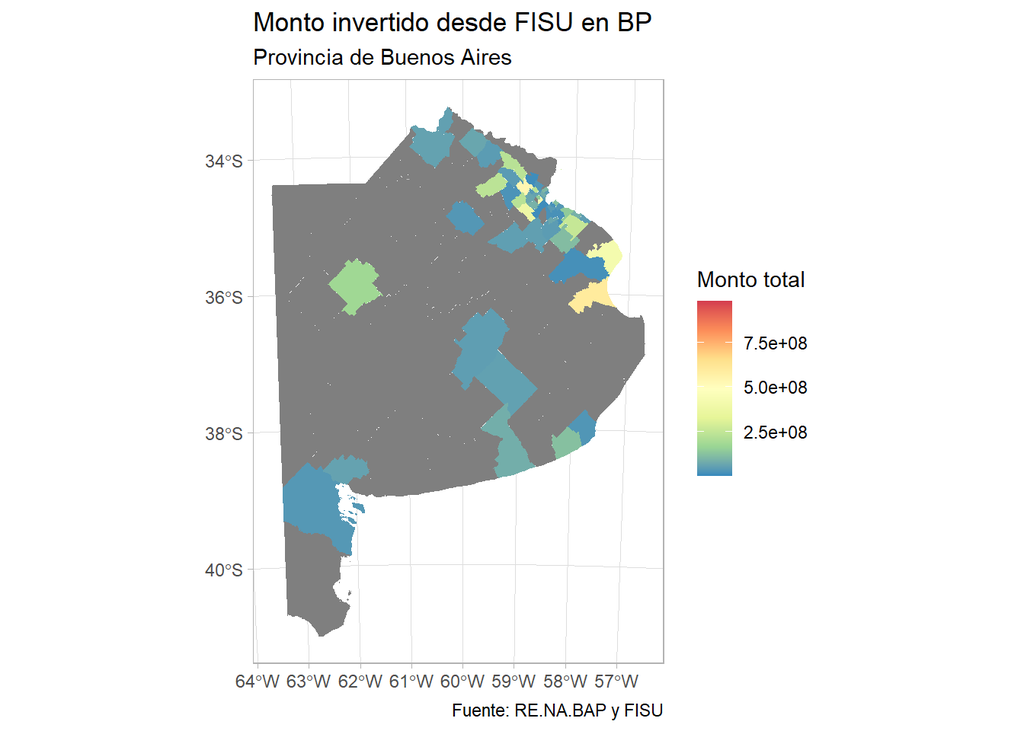

```r
ggplot()+
  geom_sf(data=inversion_fisu_pba, aes(fill=monto_total), color=NA) +
    labs(title = "Monto invertido desde FISU en BP",
         subtitle = "Provincia de Buenos Aires",
         fill = "Monto total",
         caption= "Fuente: RE.NA.BAP y FISU") +
  scale_fill_distiller(palette = "Spectral") +
  theme_light()
```